What is Advertised on Google in Croatia – a Visualization

lsimek.github.io

This notebook is part of the repository at https://github.com/lsimek/ad1.

# Introduction

This notebook deals with data about advertisements shown by Google, with data collected from the new [Google Ads Transparency Center](https://adstransparency.google.com/). There is multifold motivation for this project, but one is most prominent – transparency. With ever greater saturation of the digital space with advertising, it only makes sense to hold advertisers and others who profit accountable in cases where their activities may be considered dubious, shady, illegal or otherwise harmful. While most advertising contains some form of skewing of the truth in an effort to influence potential customers, in recent times there has been particular outcry over a digital ecosystem ever more populated with, to put it facetiously but simply, the kind of advertisements previously seen only on pornographic websites. Through systematic analysis of collected data about advertisements, we can in theory investigate both patterns and specific actors, thereby separating facts from talking points and painting a clear picture both for individuals and institutions.

Unfortunately, the data offered by Google's transparency center is quite lackluster. A number of parameters one would expect to see are not shown, e.g. money spent on the advertisement, audience response rates, specific criteria used for targeting (as opposed to only which categories either were or were not used) or keywords used. To expand on the latter, while an ad's contents can be seen on a given location given by an URL, it is not in any way given in the table. While the topic column is displayed, it is quite broad, with harmful content like ads promoting gambling being euphemistically classified as 'hobbies, games & leisure'. Interestingly, data about the number of times that an ad was shown is available only in the EEA area with Turkey, as this is the legal requirement in exactly those areas. The other table, involving removed advertisements, is even more lackluster. In it, the advertiser is not shown and the contents of the advertisement cannot be seen anywhere.

For exactly how the data was gathered, see the `collecting-data.ipynb` notebook. You can also download the dataset for yourself on [Kaggle](https://www.kaggle.com/datasets/lukasimek/google-ads-croatia). This notebook will focus mainly on visualizations. All plots can be found within the `plots/` folder.

## Imports and Configuration

```python
# standard Python utilities
import itertools
from pathlib import Path
data_path = Path('data/')
flags_path = Path('pixel-flags/flags/')
plots_path = Path('plots/')
cjk_font_path = Path('/usr/share/fonts/opentype/noto/NotoSansCJK-Bold.ttc')
for path in [data_path, flags_path, plots_path]:
    path.mkdir(parents=True, exist_ok=True)

# scientific
import numpy as np
import pandas as pd

# visualization
import matplotlib.pyplot as plt
from matplotlib.patches import Patch
from matplotlib.offsetbox import OffsetImage, AnnotationBbox

from matplotlib.dates import DateFormatter
monthly_formatter = DateFormatter('%B %Y')

%matplotlib inline
plt.style.use('https://raw.githubusercontent.com/tinjano/matplotlibrc/main/lavender-dark-thick.mplstyle')
import seaborn as sns


# auxiliary module
import aux

# silence warnings for
# presentation purposes
import warnings
warnings.simplefilter('ignore')
```

## Data

```python
df = pd.read_parquet(data_path/'google-ads-hr-2.parquet')
df_removed = pd.read_parquet(data_path/'google-ads-hr-removed-2.parquet')
```

### Some Additional Cleaning

There are some remaining problems in the dataset:

- sometimes advertiser names have leading spaces or a different suffix in some instances, creating seemingly different advertisers
- some upper bounds of impression counts are 2^64-1 either due to error or to signal there is no upper bound; they will be made equal to the lower bounds

```python
df.advertiser_disclosed_name = df.advertiser_disclosed_name.str.strip(' .\/\\\'\"\(\),`[]{};\n\t:')
df.times_shown_upper[df.times_shown_upper > 2 ** 50] = df.times_shown_lower
df_removed.times_shown_upper[df_removed.times_shown_upper > 2 ** 50] = df_removed.times_shown_lower
```

# Relative Frequencies

```python
base_dims = np.array(plt.rcParams.get('figure.figsize'))
```

```python
bool_dict = {
    True: 'yes',
    False: 'no'
}
```

```python
pie_kwargs = {
    'autopct': '%1.1f%%',
    'textprops': {'color': plt.rcParams.get('axes.facecolor')},
    'wedgeprops': {'linewidth': 0.3}
}
```

```python
def piechart(ax, labels, x, k=None, **kwargs):
    """
    piechart function
    if k is set, the set is reduced to the top k categories
    and others are grouped into 'other'
    """
    if k is not None:
        labels, x = np.append(labels[:k].astype('str'), 'other'), np.append(x[:k], x[k:].sum())

    patches, texts, autotexts = ax.pie(labels=labels, x=x, **kwargs)
    for patch, text in zip(patches, texts):
        patch.set_edgecolor('#000')
        text.set_color(plt.rcParams['text.color'])

    return patches, texts, autotexts
```

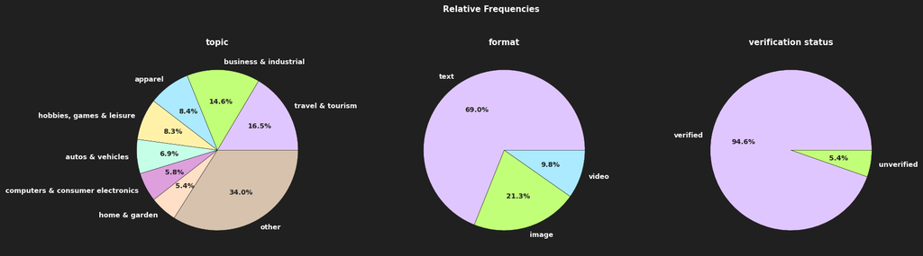

```python
fig, ax = plt.subplots(1, 3, figsize=base_dims * np.array([3, 1]))
ax_iter = iter(ax.flatten())
fig.suptitle('Relative Frequencies', y=1.05)

ax=next(ax_iter)
srs = df.topic.value_counts()
piechart(ax, labels=srs.index, x=srs, k=7, **pie_kwargs)
ax.set_title('topic')

ax=next(ax_iter)
srs = df.ad_format_type.value_counts()
piechart(ax, labels=srs.index, x=srs, **pie_kwargs)
ax.set_title('format')

ax=next(ax_iter)
srs = df.advertiser_verification_status.value_counts()
piechart(ax, labels=srs.index, x=srs, **pie_kwargs)
ax.set_title('verification status')

plt.savefig(plots_path/'relative-freq-1.png', bbox_inches='tight')
```

The following shows the use of selection criteria (used or not used).

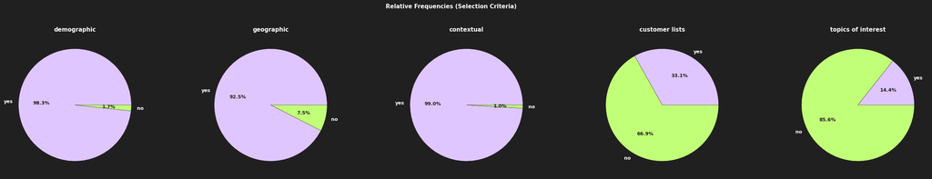

```python
fig, ax = plt.subplots(1, 5, figsize=base_dims * np.array([5, 1]))
fig.suptitle('Relative Frequencies (Selection Criteria)', y=1.05)

for col, ax_, title in zip(
    [col for col in df.columns if col.startswith('selection')],
    ax,
    ['demographic', 'geographic', 'contextual', 'customer lists', 'topics of interest']
):
    srs = df[col].value_counts().sort_index(ascending=False)
    labels = list(map(bool_dict.get, srs.index))
    piechart(ax_, labels=labels, x=srs, **pie_kwargs)
    ax_.set_title(title)

plt.savefig(plots_path/'relative-freq-2-selection.png', bbox_inches='tight')
```

Now we explore the distribution of advertiser locations. There is a large difference between the most common locations overall, and those who garnered the most impressions (top 1000 shown here).

```python
k = 1000
topk = (
    df.groupby('advertiser_disclosed_name')
    .agg({
        'times_shown_lower': 'sum',
        'advertiser_location': 'first'
    })
    .sort_values(by='times_shown_lower', ascending=False)
    .iloc[:k, :]
)
```

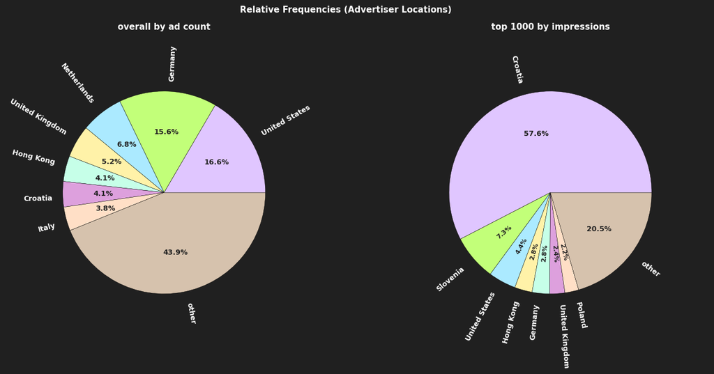

```python
fig, (ax1, ax2) = plt.subplots(1, 2, figsize=base_dims * np.array([2.5, 1.5]))
fig.suptitle('Relative Frequencies (Advertiser Locations)', y=0.95)

srs = df.advertiser_location.value_counts()
piechart(ax1, labels=srs.index, x=srs, k=7, **pie_kwargs, radius=0.8, rotatelabels=True)
ax1.set_title('overall by ad count')

srs = topk.advertiser_location.value_counts()
patches, texts, autotexts = piechart(ax2, labels=srs.index, x=srs, k=7, **pie_kwargs, radius=0.8, rotatelabels=True)
ax2.set_title(f'top {k} by impressions')

# remove autotext intersections
pcts = (srs.values.cumsum() + np.roll(srs.values, 1).cumsum()) / 2 / srs.values.sum()
for pct, autotext in zip(pcts, autotexts):
    ratio = float(autotext.get_text()[:-1]) / 100
    if ratio < 0.1:
        autotext.set_size(8)
        autotext.set_rotation(pct * 360 + 180 * (0.5 < pct < 0.75))

plt.savefig(plots_path/'relative-freq-3-location.png', bbox_inches='tight')
```

# Top 100 Advertisers

It is interesting to determine which particular advertisers are, by some definition, most influential. For this definition we will choose the total number of impressions (times that their ads were shown). Alternatives are total count of ads published or total number of active days, but these measures would overrepresent ads that were not mainly intended to be shown in Croatia, even if they were shown there as well. Another interesting measure is the number of impressions per single ad, measuring quality over quantity. Also interesting are restrictions to certain topics, formats or locations. To reduce clutter in this notebook, many of these alternatives are explored in the `topk.ipynb` notebook, while the plots can be found within the `plots/` folder.

On a technical note, we are shortening very long official advertiser names. This can be removed in cases where it is important that the entire name is displayed.

```python
# name -> location dictionary
loc_dict = (
    df.groupby('advertiser_disclosed_name')
    .agg({'advertiser_location': 'first'})
    .to_dict()
    .get('advertiser_location')
)
```

```python
k = 100

pivoted_df = df.pivot_table(
    values='times_shown_lower',
    index='advertiser_disclosed_name',
    columns='ad_format_type',
    aggfunc='sum',
    fill_value=0
)
pivoted_df['total'] = pivoted_df.sum(axis=1)

pivoted_df = (
    pivoted_df
    .sort_values(by='total', ascending=False)
    .iloc[:k, :]
    .sort_values(by='total', ascending=True)
)
```

[figure not shown]

```python
fig, ax = plt.subplots(figsize=(10, 20))

y = [aux.shorten(name, 40) for name in pivoted_df.index]
left = np.zeros(pivoted_df.shape[0])

# draw stacked bars
for ad_format_type in df.ad_format_type.unique():
    width = pivoted_df[ad_format_type]
    ax.barh(y=y, width=width, left=left, label=ad_format_type)
    left += width

plt.draw()

oom = vars(ax.get_xaxis().get_major_formatter()).get('orderOfMagnitude')
for i, (total, advertiser_disclosed_name, ticklabel) in enumerate(zip(pivoted_df.total, pivoted_df.index, ax.get_yticklabels())):
    # add value labels to the right of bars
    text = f'{total/10**oom:.2f}' if oom > 1 else str(total)
    ax.text(total, i, text, ha='left', va='center', size='smaller')

    # change font in case label contains Chinese/Japanese/Korean characters
    if aux.contains_cjk(ticklabel.get_text()):
        try:
            ticklabel.set_font(cjk_font_path)
        except FileNotFoundError:
            pass


    # place country flags before names
    location = loc_dict.get(advertiser_disclosed_name)
    try:
        abbrev = aux.country_to_abbrev.get(location).lower()
        flag_image = plt.imread(flags_path/f'{abbrev}.png')
    except (FileNotFoundError, AttributeError, KeyError):
        continue

    window_extent = ticklabel.get_window_extent().transformed(ax.transData.inverted())
    x0, y0, x1, y1 = window_extent.get_points().flatten()

    imh, imw = flag_image.shape[:2]

    zoom = (ticklabel.get_fontsize() * 0.8) / imh
    flag_offsetbox = OffsetImage(flag_image, zoom=zoom)

    flag_artist = AnnotationBbox(flag_offsetbox, xy=(0, 0), xybox=(x0, i), boxcoords='data', frameon=False, box_alignment=(1.1, 0.5))
    ax.add_artist(flag_artist)

# colloquialize offset label
# note: offset_label.set_text('...') or
# offset_label.get_text().set_text('...') wont work
offset_label = ax.get_xaxis().get_offset_text()
offset_label_text = offset_label.get_text()
x, y, _, _ =  offset_label.get_window_extent().get_points().flatten()
x, y = ax.transData.inverted().transform((x, y))

ax.text(x, y, aux.humanize_dict.get(offset_label_text))
ax.xaxis.offsetText.set_visible(False)

ax.set(
    title=f'Advertisers by Total # of Impressions (top {k})',
    xlabel='times shown (low estimate)',
)

ax.legend()
plt.savefig(plots_path/'top100.png', bbox_inches='tight')
```

## Distributions

There are two variables in the dataset that can be interpreted as continuous, those being `days_running` (nr. of days that an ad is active) and the number of impressions. Surprisingly, the correlation between the two is very close to zero (even when making some reasonable restriction), so their joint distribution is uninteresting.

With regard to the number of active days, the spike near the end of the range is likely due to the fact that many ads have still not stopped running during the relatively short time that this dataset encompasses.

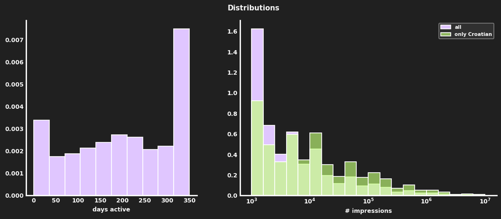

```python
fig, (ax1, ax2) = plt.subplots(1, 2, figsize=base_dims * np.array([2, 1]), width_ratios=[1, 1.5])
fig.suptitle('Distributions', y=0.95)

sns.histplot(df.days_running, bins=10, stat='density', alpha=1, ax=ax1)
ax1.set(
    xlabel='days active',
    ylabel='',
    title=''
)

sns.histplot(df.times_shown_lower, bins=20, label='all', alpha=1,
             log_scale=True, stat='density', ax=ax2)
sns.histplot(df[df.advertiser_location == 'Croatia'].times_shown_lower, bins=20, alpha=0.65,
             label='only Croatian', log_scale=True, stat='density', ax=ax2)
ax2.set(
    xlabel='# impressions',
    ylabel='',
)
ax2.legend()

plt.savefig(plots_path/'distributions.png', bbox_inches='tight')
```

## Trends

In this subsection we explore changes in certain parameters over time. We divide the dataset into weekly segments according to the first time an ads was shown (`first_shown` column). Note that:

- there is a large influx of ads at the very beginning, likely due to some aspects of the table's construction by Google
- there are very few near the end of the time range, due to the fact that we selected only ads with full information already available; thus many ads that became active very recently are not in the dataset.

Because of these two facts, we will restrict the dataset to a more suitable time interval. It would be interesting to redraw some of these graphs once a dataset with a larger timespan is available.

```python
dft = df.copy()[(df.first_shown > '2023-03-05') & (df.first_shown <= '2023-11-12')]
```

```python
time_grouper = pd.Grouper(key='first_shown', freq='w')
```

```python
def format_axes(ax, labelsize=6, formatter=monthly_formatter, rotation=30, format_legend=True, **kwargs):
    ax.tick_params(axis='x', labelsize=labelsize)
    ax.xaxis.set_major_formatter(formatter=formatter)
    for label in ax.get_xticklabels(which='major'):
        label.set(rotation=rotation)
    ax.set(**kwargs)
    if format_legend:
        ax.legend().set_title('')
```

### Formats

```python
dft_agg = (
    dft.groupby([time_grouper, 'ad_format_type'])
    .agg(
        ad_count=('creative_page_url', 'count'),
        impressions_total=('times_shown_lower', 'sum'),
        impressions_mean=('times_shown_lower', 'mean')
    )
)
```

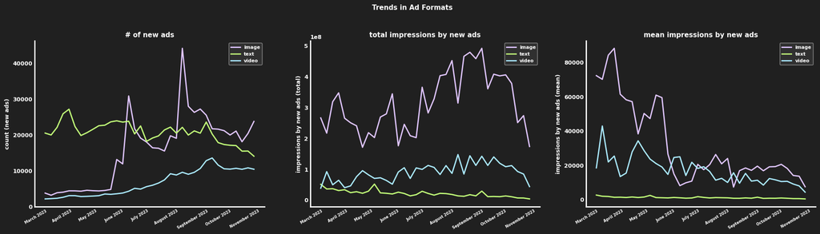

```python
fig, (ax1, ax2, ax3) = plt.subplots(1, 3, figsize=base_dims * np.array([3.5, 1]))
fig.suptitle('Trends in Ad Formats', y=1.05)

sns.lineplot(
    data=dft_agg,
    x='first_shown',
    y='ad_count',
    hue='ad_format_type',
    ax=ax1
)
format_axes(ax1, title='# of new ads', xlabel='', ylabel='count (new ads)')

sns.lineplot(
    data=dft_agg,
    x='first_shown',
    y='impressions_total',
    hue='ad_format_type',
    ax=ax2
)
format_axes(ax2, title='total impressions by new ads', xlabel='', ylabel='impressions by new ads (total)')

sns.lineplot(
    data=dft_agg,
    x='first_shown',
    y='impressions_mean',
    hue='ad_format_type',
    ax=ax3
)
format_axes(ax3, title='mean impressions by new ads', xlabel='', ylabel='impressions by new ads (mean)')

plt.savefig(plots_path/'trends-format.png', bbox_inches='tight')
```

### Verification Status

```python
dft_agg = (
    dft.groupby([time_grouper, 'advertiser_verification_status'])
    .agg(
        ad_count=('creative_page_url', 'count'),
        impressions_total=('times_shown_lower', 'sum'),
        advertiser_count=('advertiser_disclosed_name', 'nunique')
    )
    .reset_index()
)
```

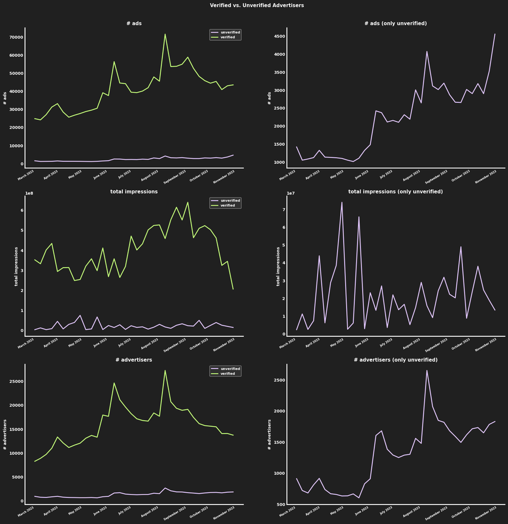

```python
fig, ax = plt.subplots(3, 2, figsize=base_dims * np.array([3, 4]))
fig.suptitle('Verified vs. Unverified Advertisers', y=0.92)

for ax_, colname, xlabel, ylabel, title in zip (
    ax[:, 0], ['ad_count', 'impressions_total', 'advertiser_count'], ['', '', ''],
    ['# ads', 'total impressions', '# advertisers'], ['# ads', 'total impressions', '# advertisers']
):
    sns.lineplot(
        data=dft_agg,
        x='first_shown',
        y=colname,
        hue='advertiser_verification_status',
        ax=ax_
    )
    format_axes(ax_, title=title, xlabel=xlabel, ylabel=ylabel)

for ax_, colname, xlabel, ylabel, title in zip (
    ax[:, 1], ['ad_count', 'impressions_total', 'advertiser_count'], ['', '', ''],
    ['# ads', 'total impressions', '# advertisers'], ['# ads (only unverified)', 'total impressions (only unverified)', '# advertisers (only unverified)']
):
    sns.lineplot(
        data=dft_agg[dft_agg.advertiser_verification_status == 'unverified'],
        x='first_shown',
        y=colname,
        ax=ax_
    )
    format_axes(ax_, format_legend=False, title=title, xlabel=xlabel, ylabel=ylabel)

plt.savefig(plots_path/'trends-verif.png', bbox_inches='tight')
```

### Topics

We explore the popularity, absolute and relative, of different topics. In order not to clutter the plots, we reduce the set of topics to a certain top $k$ and 'other'.

```python
k = 9
top_k_cats = dft.topic.value_counts().index[:k]
dft.topic = dft.topic.cat.add_categories('other')
dft.loc[~dft.topic.isin(top_k_cats), 'topic'] = 'other'
dft.topic = dft.topic.cat.remove_unused_categories()
```

```python
dft_agg = (
    dft.groupby([time_grouper, 'topic'])
    .agg(
        ad_count=('creative_page_url', 'count'),
        advertiser_count=('advertiser_disclosed_name', 'nunique'),
        impressions_total=('times_shown_lower', 'sum'),
        impressions_mean=('times_shown_lower', 'mean')
    )
    .reset_index()
)
```

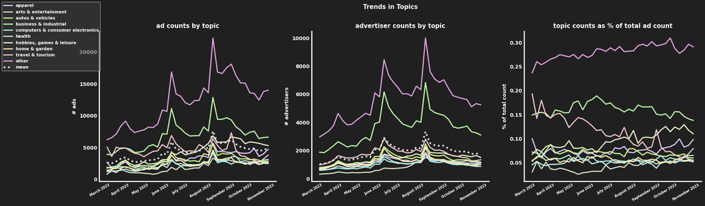

```python
fig, (ax1, ax2, ax3) = plt.subplots(1, 3, figsize=base_dims * np.array([3, 1]))
fig.suptitle('Trends in Topics', y=1.02)

sns.lineplot(
    data=dft_agg,
    x='first_shown',
    y='ad_count',
    hue='topic',
    palette=sns.blend_palette(['C0', 'C1', 'C2', 'C3', 'C5'], n_colors=dft.topic.nunique()),
    ax=ax1
)

sns.lineplot(
    dft_agg.groupby('first_shown').ad_count.mean(),
    linewidth=3,
    color='#ddd',
    linestyle=':',
    label='mean',
    ax=ax1
)
format_axes(ax1, title='ad counts by topic', xlabel='', ylabel='# ads')

sns.lineplot(
    data=dft_agg,
    x='first_shown',
    y='advertiser_count',
    hue='topic',
    palette=sns.blend_palette(['C0', 'C1', 'C2', 'C3', 'C5'], n_colors=dft.topic.nunique()),
    ax=ax2
)

sns.lineplot(
    dft_agg.groupby('first_shown').advertiser_count.mean(),
    linewidth=3,
    color='#ddd',
    linestyle=':',
    label='mean',
    ax=ax2
)
format_axes(ax2, title='advertiser counts by topic', xlabel='', ylabel='# advertisers')

dft_agg.ad_count = dft_agg.ad_count / dft_agg.groupby('first_shown').ad_count.transform('sum')
sns.lineplot(
    data=dft_agg,
    x='first_shown',
    y='ad_count',
    hue='topic',
    palette=sns.blend_palette(['C0', 'C1', 'C2', 'C3', 'C5'], n_colors=dft.topic.nunique()),
    ax=ax3
)
format_axes(ax3, title='topic counts as % of total ad count', xlabel='', ylabel='% of total count')

# set figure-wide legend
handles, labels = ax1.get_legend_handles_labels()
fig.legend(handles, labels, loc='upper left')
for ax_ in [ax1, ax2, ax3]:
    ax_.legend().remove()

plt.savefig(plots_path/'trends-topic.png', bbox_inches='tight')
```

# Removed Ads

In this section we turn our attention to data about ads that were removed by Google.

## New Categories

There are two specific categories for removed ads, being whether it was removed by use of automatic means, and whether it was removed because of a Google investigation or a legal notice

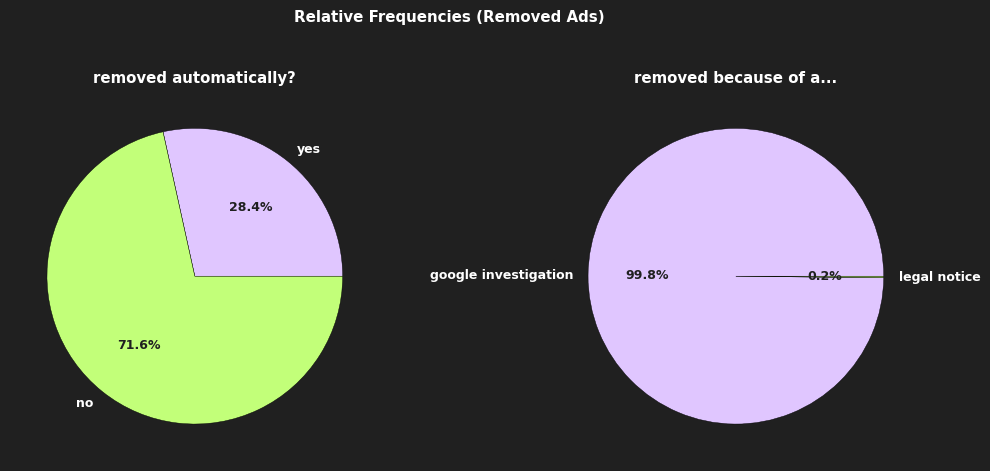

```python
fig, ax = plt.subplots(1, 2, figsize=base_dims * np.array([2, 1]))
fig.suptitle('Relative Frequencies (Removed Ads)', y=1.05)
ax_iter = iter(ax.flatten())

ax = next(ax_iter)
srs = df_removed.automated.value_counts().sort_index(ascending=False)
labels=list(map(bool_dict.get, srs.index))
piechart(ax, labels=labels, x=srs, **pie_kwargs)
ax.set_title('removed automatically?')

ax = next(ax_iter)
srs = df_removed.decision_type.value_counts()
piechart(ax, labels=list(map(str.lower, srs.index)), x=srs, **pie_kwargs)
ax.set_title('removed because of a...')

plt.savefig(plots_path/'relative-freq-removed.png', bbox_inches='tight')
```

## Comparison with Other Ads

```python
df['removed'] = False
df_removed['removed'] = True
df_all = pd.concat([df, df_removed], axis=0)
```

```python
pie_kwargs = {
    'autopct': '%1.1f%%',
    'textprops': {'color': plt.rcParams.get('axes.facecolor')},
    'wedgeprops': {'linewidth': 0.3}
}
```

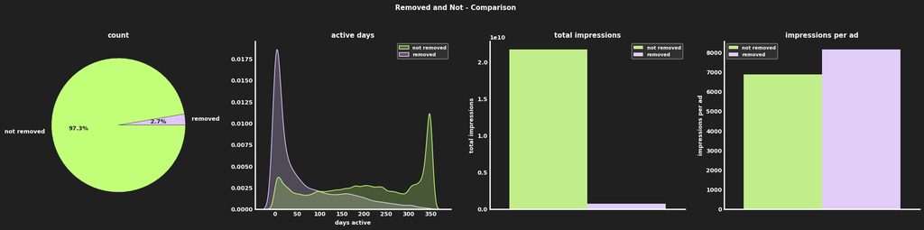

```python
fig, ax = plt.subplots(1, 4, figsize=base_dims * np.array([4, 1]))
fig.suptitle('Removed and Not - Comparison', y=1.05)
ax_arr = ax.flatten()
ax_iter = iter(ax.flatten())

# make sure colors are always assigned the same way
color_map = {
    True: 'C0',
    False: 'C1'
}

ax = next(ax_iter)
srs = df_all.removed.value_counts().sort_index(ascending=False)
di = {
    True: 'removed',
    'True': 'removed',
    False: 'not removed',
    'False': 'not removed'
}
piechart(ax, labels=list(map(di.get, srs.index)), x=srs, **pie_kwargs, colors=list(map(color_map.get, srs.index)))
ax.set_title('count')

ax = next(ax_iter)
sns.kdeplot(
    data=df_all,
    x='days_running',
    hue='removed',
    common_norm=False,
    fill=True,
    palette=color_map,
    ax=ax
)
ax.set(xlabel='days active', ylabel='', title='active days')


ax = next(ax_iter)

df_all_agg = (
    df_all.groupby('removed')
    .agg(
        total_impressions=('times_shown_lower', 'sum'),
        mean_impressions=('times_shown_lower', 'mean')
    )
)

sns.barplot(
    data=df_all_agg,
    y='total_impressions',
    hue='removed',
    palette=color_map,
    ax=ax
)
ax.set(ylabel='total impressions', title='total impressions')

ax = next(ax_iter)
sns.barplot(
    data=df_all_agg,
    y='mean_impressions',
    hue='removed',
    palette=color_map,
    ax=ax
)
ax.set(ylabel='impressions per ad', title='impressions per ad')

for ax in ax_arr:
    legend = ax.get_legend()
    if legend is None:
        continue
    legend.set_title('')
    for text_object in legend.get_texts():
        text_object.set_text(
            di.get(text_object.get_text())
        )

plt.savefig(plots_path/'removed-comparison.png', bbox_inches='tight')
```

## Violation Categories and Removal Reasons

Each removal is given one of four broad removal categories, and each is further divided into several subcategories called removal reasons. Note that some of the very rare reasons are not explicitly listed on the plot.

```python
reasons_frame = (
    df_removed.groupby(['violation_category', 'removal_reason'])
    .agg(
        count_=('creative_page_url', 'count')
    )
    .reset_index()
    .sort_values(['violation_category', 'count_'], ascending=[True, False])
    .query('count_ > 0')
)

base_color_map = {category: f'C{i}' for i, category in enumerate(reasons_frame.violation_category.unique())}

colors = []
category_sizes = (
    reasons_frame
    .groupby('violation_category')
    .agg(size_=('removal_reason', 'count'))
)

for category, n in zip(
    category_sizes.index,
    category_sizes.size_
):
    colors += sns.dark_palette(
        color=base_color_map.get(category),
        n_colors=n,
        reverse=True
    )

full_palette = sns.color_palette(colors)
full_color_map = {reason: color for reason, color in zip(reasons_frame.removal_reason.unique(), list(full_palette))}
```

```python
# returns True if color in rgba format is 'light'
is_light = lambda color_rgba: np.linalg.norm(color_rgba * np.array([0.299, 0.587, 0.114, 0])) > 0.5
```

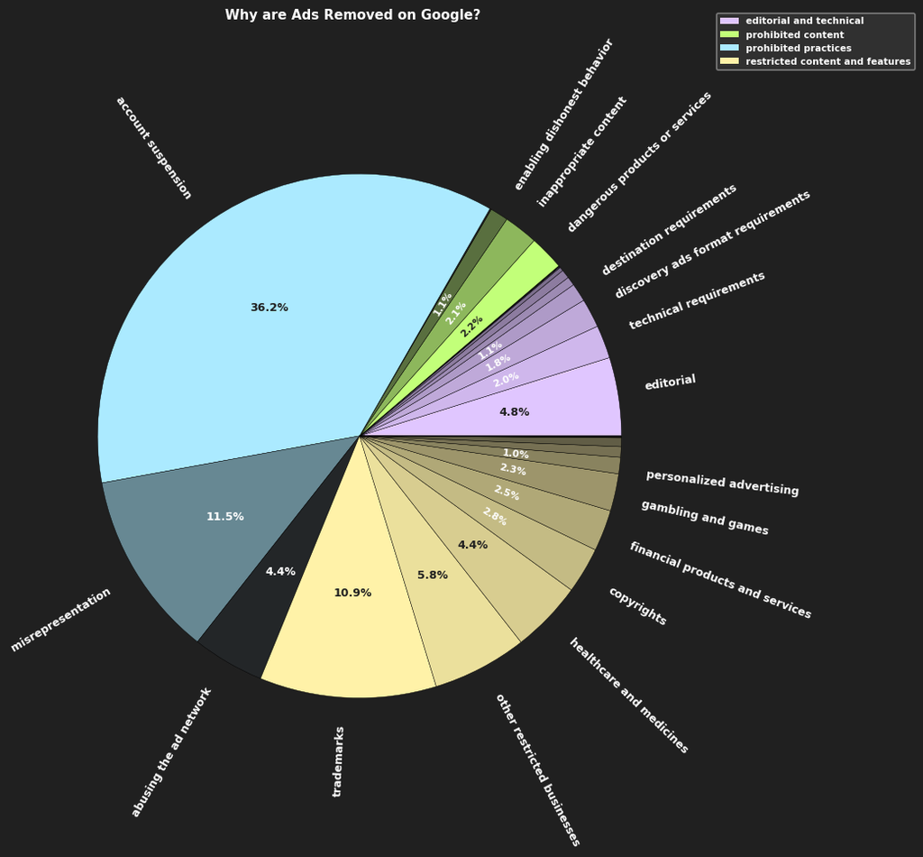

```python
fig, ax = plt.subplots(figsize=base_dims)
dy = 0.5  # distance on y axis for suptitle and legend
fig.suptitle('Why are Ads Removed on Google?', y=1 + dy)

wedges, texts, autotexts = piechart(
    ax,
    labels=reasons_frame.removal_reason, x=reasons_frame.count_,
    colors=list(map(full_color_map.get, reasons_frame.removal_reason.values)),
    **pie_kwargs, rotatelabels=True, radius=2
)

# add legend explaining violation categories
handles = [Patch(facecolor=color, label=label) for label, color in base_color_map.items()]
fig.legend(handles, base_color_map.keys(), loc='upper right', bbox_to_anchor=(1, dy, 0.5, 1))

# rotate percentage labels in small slices
# & remove all labels in very small slices
# & change text color depending on background brightness
srs = reasons_frame.count_
pcts = (srs.values.cumsum() + np.roll(srs.values, 1).cumsum()) / 2 / srs.values.sum()
for pct, wedge, text, autotext in zip(pcts, wedges, texts, autotexts):
    ratio = float(autotext.get_text()[:-1]) / 100
    if ratio < 0.03 and ratio >= 0.01:
        autotext.set_size(8)
        autotext.set_rotation(pct * 360 + 180 * (0.5 < pct < 0.75))
    elif ratio < 0.01:
        text.set_text('')
        autotext.set_text('')

    if not is_light(wedge.get_facecolor()):
        autotext.set_color(plt.rcParams.get('text.color'))

plt.savefig(plots_path/'rel-freq-removed-reasons.png', bbox_inches='tight')
```

### Active Days Depending on Category

Earlier we saw that ads that are removed do often get removed relatively quickly. To be precise: 25% of removed ads will be removed within 4 days and 50% within a month (26 days is the 50th percentile). However, a different 25% percent will stay on for at least around 3 months (105 days is the 75th percentile). Here we explore how this varies across the violation categories and removal reasons.

The below plots can be redrawn with the default palette when greater visibility is needed.

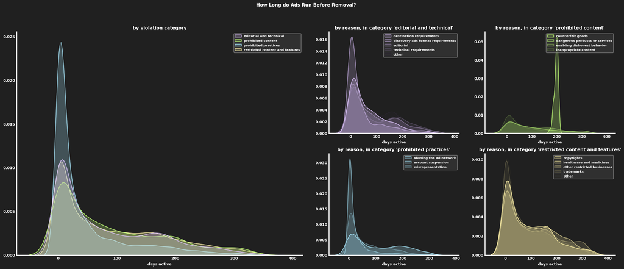

```python
fig = plt.figure(figsize=base_dims * np.array([4, 2]))
fig.suptitle('How Long do Ads Run Before Removal?')

ax_main = plt.subplot2grid((2, 4), (0, 0), rowspan=2, colspan=2)

ax_sec = []
for row, col in itertools.product([0, 1], [2, 3]):
    ax_sec.append(
        plt.subplot2grid((2, 4), (row, col), 1, 1)
    )

sns.kdeplot(
    data=df_removed,
    x='days_running',
    common_norm=False,
    hue='violation_category',
    palette=base_color_map,
    fill=True,
    ax=ax_main
)
ax_main.get_legend().set_title('')
ax_main.set(xlabel='days active', ylabel='', title='by violation category')

k = 4  # for visual clarity, only display top k reasons
for ax, category in zip(ax_sec, base_color_map.keys()):
    current_frame = df_removed[df_removed.violation_category == category].copy()

    value_counts_series = current_frame.removal_reason.value_counts()
    if len(value_counts_series) > k + 1:
        top_k_cats = current_frame.removal_reason.value_counts().index[:k]
        current_frame.removal_reason = current_frame.removal_reason.cat.add_categories('other')
        current_frame.loc[~current_frame.removal_reason.isin(top_k_cats), 'removal_reason'] = 'other'
        current_frame.removal_reason = current_frame.removal_reason.cat.remove_unused_categories()

    sns.kdeplot(
        data=current_frame,
        x='days_running',
        common_norm=False,
        hue='removal_reason',
        palette=sns.dark_palette(
            color=base_color_map.get(category),
            n_colors=min(k+1, len(value_counts_series)),
            reverse=True
        ),
        fill=True,
        ax=ax
    )

    ax.get_legend().set_title('')
    ax.set(xlabel='days active', ylabel='', title=f'by reason, in category \'{category}\'')

plt.savefig(plots_path/'removed-by-category.png', bbox_inches='tight')
```

## Trends

Once again, we investigate changes over time on a restricted range of time. This time, we group the ads by the time they were last shown, thus any values are in respect to the ads removed that week. As in the last plot, it can be redrawn for better visibility.

```python
dft_removed = df_removed.copy()[(df_removed.last_shown > '2023-03-05') & (df_removed.last_shown <= '2023-11-12')]
```

```python
time_grouper = pd.Grouper(key='last_shown', freq='w')
```

```python
dft_agg = (
    dft_removed.groupby([time_grouper, 'violation_category'])
    .agg(
        count_=('creative_page_url', 'count')
    )
    .reset_index()
    .pivot_table(
        values='count_',
        index='last_shown',
        columns='violation_category',
        aggfunc='sum',
        fill_value=0
    )
    .reset_index()
)
```

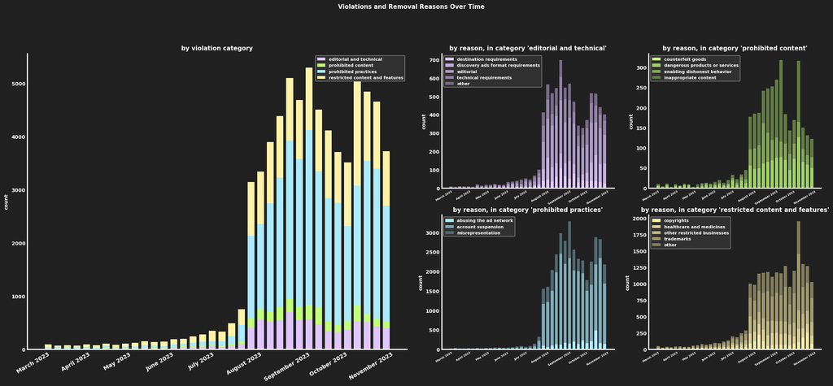

```python
fig = plt.figure(figsize=base_dims * np.array([4, 2]))
fig.suptitle('Violations and Removal Reasons Over Time', y=1.01)

ax_main = plt.subplot2grid((2, 4), (0, 0), rowspan=2, colspan=2)

ax_sec = []
for row, col in itertools.product([0, 1], [2, 3]):
    ax_sec.append(
        plt.subplot2grid((2, 4), (row, col), 1, 1)
    )

x = dft_agg.last_shown
bottom = np.zeros(dft_agg.shape[0])
for category in base_color_map.keys():
    height = dft_agg[category].values
    ax_main.bar(x=x, height=height, bottom=bottom, width=5, label=category)
    bottom += height

ax_main.legend()
format_axes(ax_main, title='by violation category', xlabel='', ylabel='count', labelsize=10)

k = 4  # for visual clarity, only display top k reasons
for ax, category in zip(ax_sec, base_color_map.keys()):
    srs = df_removed[df_removed.violation_category == category].removal_reason.value_counts()
    all_reasons = srs.index[srs.values > 0].values
    top_k_cats = srs.index.values[:k]
    # print(category, top_k_cats)

    current_frame = (
        dft_removed[dft_removed.violation_category == category]
        .groupby([time_grouper, 'removal_reason'])
        .agg(
            count_=('creative_page_url', 'count')
        )
        .reset_index()
        .pivot_table(
            values='count_',
            index='last_shown',
            columns='removal_reason',
            aggfunc='sum',
            fill_value=0
        )
    )
    current_frame = current_frame.loc[:, current_frame.columns.isin(all_reasons)]

    if len(current_frame.columns) - 1 > k + 1:
        current_frame['other'] = current_frame.loc[:, ~current_frame.columns.isin(top_k_cats)].sum(axis=1, numeric_only=True)
        current_frame = current_frame.loc[:, [col for col in current_frame.columns if col in top_k_cats or col == 'other']]

    x = current_frame.index
    bottom = np.zeros(current_frame.shape[0])
    palette = sns.dark_palette(base_color_map.get(category), int(len(current_frame.columns) * 1.6), reverse=True)[:len(current_frame.columns)]

    for reason, color in zip(current_frame.columns, palette):
        height = current_frame[reason].values
        ax.bar(x=x, height=height, bottom=bottom, width=5, label=reason, color=color)
        bottom += height

    ax.legend()
    format_axes(ax, xlabel='', ylabel='count', title=f'by reason, in category \'{category}\'', labelsize=5)

plt.savefig(plots_path/'removed-trends.png', bbox_inches='tight')
```